# Oblig 1

## Teoretisk bakgrunn

Et komplekst tall består av en realdel og en imaginær del. Det kan skrives på kartesisk form slik:
$$ z = a + bi $$ hvor $i = \sqrt{-1}$,
eller på polar form:
$$ z = re^{i\theta} $$ hvor $r$ er den absolutte lengden til vektoren som representerer $z$ i det komplekse planet, og $\theta$ er vinkelen til vektoren i forhold til x-aksen.

Formelen for å oversette mellom kartesisk og polar form er gitt ved:
$$ z = a + bi $$ $$ z = \sqrt{a^2 + b^2} \cdot e^{i \tan^{-1}\left( \frac{b}{a} \right)} $$ Dette kan vises geometrisk.

Når et komplekst tall opphøyes i annen potens, kvadreres den absolutte lengden av vektoren som representerer tallet i det komplekse planet, mens vinkelen dobles: $$ z = re^{i\theta} $$ $$ z^2 = r^2 e^{i \cdot 2\theta} $$

## Oppgaven

$$ z^n = a $$

For å løse denne ligningen tar vi $n$-te roten på begge sider: $$ z = a^{\frac{1}{n}} $$

Dette gir oss en gyldig løsning som vi kan kalle for $z_0$. Vi sier at $a = re^{i\theta}$ og får: $$ z_0 = \left( re^{i\theta} \right)^{\frac{1}{n}} $$ Som kan skrives som: $$ z_0 = r^{\frac{1}{n}} e^{i\frac{\theta}{n}} $$

Kvadratroten av et komplekst tall $z$ har to løsninger, hvor: $$ z_{1, \theta} = z_{0, \theta} + \pi $$ Dette er fordi $z^2$ har vinkelen $2\theta$. Altså vil det ekstra leddet $\pi$ bli til $2\pi$, som tilsvarer en full runde i det komplekse planet. Altså er $z_0^2$ og $z_1^2$ like hvis vinkelen er $\pi$ forskjellig og den absolutte lengden er lik.

Den samme logikken gjelder for kubikkrøtter, osv.  
Man kan legge $\frac{2\pi k}{n}$ til vinkelen for $k = 0, 1, 2, \ldots, n-1$, hvor $n$ er den naturlige roten, og fortsatt få samme svar.  
Vi legger dette til i utregningen vår:

$$ z = r^{\frac{1}{n}} e^{i \left( \frac{\theta}{n} + \frac{2\pi k}{n} \right)}, \quad k = 0, 1, 2, \ldots, n-1 $$

eller mer kompakt:

$$ z = r^{\frac{1}{n}} e^{i \frac{\theta + 2\pi k}{n}}, \quad k = 0, 1, 2, \ldots, n-1 $$

Vi regner med oversettelsen fra det komplekse tallet vi får inn på kartesisk form:

$$ a = x + yi $$ $$ z = \left( x^2 + y^2 \right)^{\frac{1}{2n}} e^{i \frac{\tan^{-1}\left( \frac{y}{x} \right) + 2\pi k}{n}}, \quad k = 0, 1, 2, \ldots, n-1 $$

Dette vil gi oss alle løsninger for ligningen.  
Når vi skal plotte svaret, behøver vi å oversette tilbake til kartesisk form. Dette gjøres ved formelen:

$$ z = re^{i\theta} $$ $$ z_x = r \cos(\theta) $$ $$ z_y = r \sin(\theta) $$

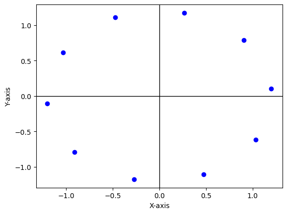

```python
import numpy as np # Importer biblioteker
import matplotlib.pyplot as plt

x = float(input("Real part: ")) # Ta inn a på kartesisk form
y = float(input("Imaginary part: "))

n = int(input("Natural number: ")) # Ta inn det natulige tallet n

r = np.power(x**2+y**2, 1/(2*n)) # Regm ut den absolutte lengden til alle løsningene, som er felles

theta = 0

if x == 0:
  if y > 0:
    theta = np.pi
  else:
    theta = -np.pi
else:
  theta = np.atan(y/x)

sols_x = [] # Arrays for å lage koordinatene til løsningene
sols_y = []

for k in range(0, n): # Loop gjennom løsninger fra k=0 til k=n-1
  ang = (theta+2*np.pi*k)/n # Løsningen på polarform
  sols_x.append(r*np.cos(ang)) # Omregnes til kartesisk form
  sols_y.append(r*np.sin(ang))

plt.scatter(sols_x, sols_y, color='blue')

plt.axhline(0, color='black', linewidth=1)
plt.axvline(0, color='black', linewidth=1)

plt.xlabel("X-axis")
plt.ylabel("Y-axis")

plt.show()
```